# Projeto AV1 - Introdução ao R aplicado a CD

Edilton Brandão

2023-04-12

## Sobre a base de dados

A base do projeto trata-se de um conjunto de dados sobre as causas de morte em todo o mundo. Os dados incluem o número anual de mortes por causa, como doenças cardíacas, câncer, doenças respiratórias, acidentes e muito mais, para países em todo o mundo. O conjunto de dados é fornecido pela Our World in Data, uma organização sem fins lucrativos que se dedica a fornecer informações e análises baseadas em evidências sobre os principais problemas globais.

Download dos dados: [Causes of Death - Our World In Data | Kaggle](https://www.kaggle.com/datasets/ivanchvez/causes-of-death-our-world-in-data)

## Leitura dos dados

**Gráfico de barras com as 5 maiores causas de mortes no mundo**

Este gráfico foi construído a partir da contagem do número total de mortes por cada causa, levando em consideração todos os anos e países presentes na base de dados. O gráfico de barras apresenta as 5 principais causas de morte.

```r
# Carreganso as bibliotecas necessárias
library(tidyverse)
library(magrittr)
library(dplyr)
Sys.setlocale("LC_CTYPE", "pt_BR.UTF-8")
```

```
## [1] "pt_BR.UTF-8"
```

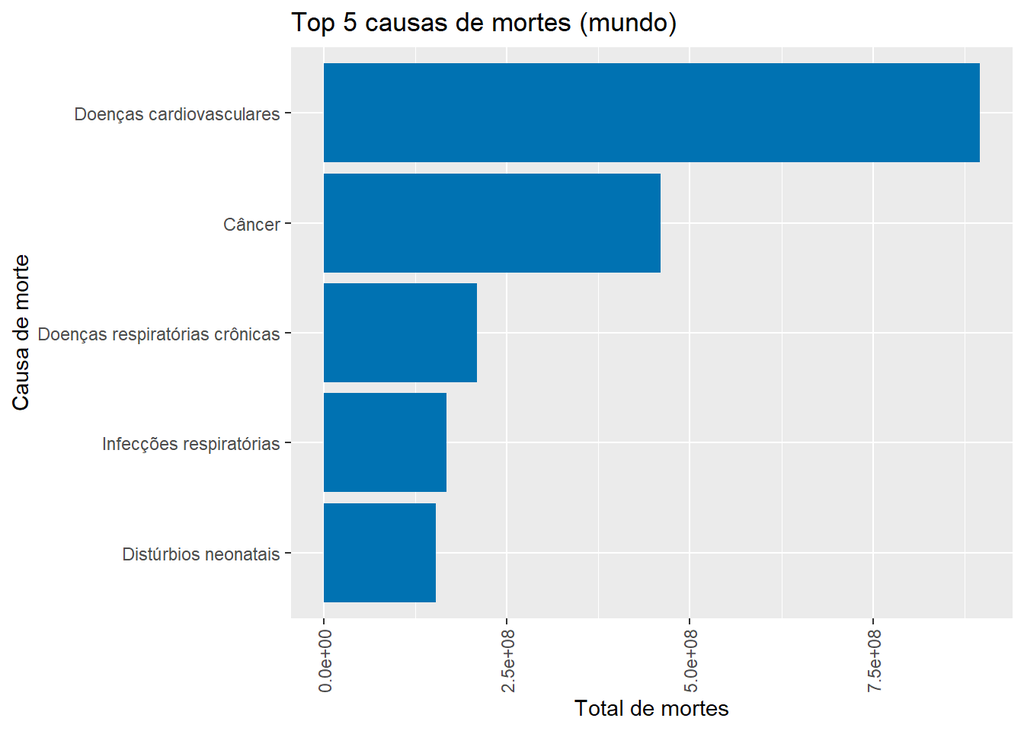

```r
# Carregando o conjunto de dados
causas_morte <- read.csv("https://raw.githubusercontent.com/edilton-bs/intro-r/main/av1/dados/deaths.csv")


# Substituindo espaços em branco e strings vazias por NA
dados_com_na <- causas_morte %>%
  mutate_all(funs(ifelse(. == "" | . == " ", NA, .)))

# Transformando o conjunto de dados para um formato longo, onde cada linha representa um país, código, um ano, uma causa de morte e o número de mortes associadas

dados_longos <- dados_com_na %>%
  gather(key = "Causa", value = "Mortes", Number.of.executions..Amnesty.International.:Deaths...Parkinson.s.disease...Sex..Both...Age..All.Ages..Number.) %>%
  mutate(Mortes = parse_number(Mortes))

# Pegando somente os dados sobre países, excluindo continentes e outros tipos de regiões
dados_paises <- dados_longos %>%
  filter(!is.na(Code))



# GRÁFICO DE BARRAS

# Removendo as linhas com valores NA na coluna "Mortes"
# Agrupando os dados por causa de morte e calcule o total de mortes por causa:
total_mortes_causa <- dados_paises %>%
  filter(!is.na(Mortes)) %>% group_by(Causa) %>%
  summarize(Total_Mortes = sum(Mortes, na.rm = TRUE))

# Ordenando as causas de morte por total de mortes e selecione o top 5:
top_5_causas <- total_mortes_causa %>%
  arrange(desc(Total_Mortes)) %>%
  slice(1:5)

# Criando um vetor com os nomes originais e um vetor com os novos nomes mais curtos
nomes_originais <- top_5_causas$Causa
nomes_curto <- c("Doenças cardiovasculares", "Câncer", "Doenças respiratórias crônicas", "Infecções respiratórias", "Distúrbios neonatais")

# Criando o vetor 'name_vec' usando a função 'setNames()' que servirá para mapear cada elemento de nomes_curto  ao nome do elemento correspondente em nomes_originais
name_vec <- setNames(nomes_curto, nomes_originais)

# Renomeando as colunas do data frame 'top_5_causas' de acordo com o vetor 'name_vec'
top_5_causas <- top_5_causas %>%
  mutate(Causa = recode(Causa, !!!name_vec))


# Cria um gráfico de barras horizontais
grafico_barras_horiz <- ggplot(data = top_5_causas, aes(x = Total_Mortes, y = reorder(Causa, Total_Mortes))) +
  geom_bar(stat = "identity", fill = "#0072B2") +
  labs(x = "Total de mortes", y = "Causa de morte", title = "Top 5 causas de mortes (mundo)") +
  theme(axis.text.x = element_text(angle = 90, vjust = 0.5, hjust = 1))

# Exibe o gráfico
print(grafico_barras_horiz)
```

**Evolução do número de casos de mortes para cada caso no Brasil**

Este gráfico tem como objetivo apresentar uma análise das 5 principais causas de morte no Brasil, de acordo com os dados disponíveis. Um gráfico de linha é utilizado para exibir o número total de mortes por cada uma dessas causas em cada ano.

```r
# obtendo dados somente do Brasil
dados_brasil <- dados_paises %>%
  filter(Code == "BRA" & !is.na(Mortes))

# Filtra os dados para as cinco principais causas de morte no Brasil
top_5_causas_brasil <- dados_brasil %>%
  group_by(Causa) %>%
  summarize(Total_Mortes = sum(Mortes, na.rm = TRUE)) %>%
  arrange(desc(Total_Mortes)) %>%
  slice(1:5)


# Filtrando o data frame original para incluir apenas as 5 maiores causas de morte
dados_filtrados <- dados_brasil %>%
  filter(Causa %in% top_5_causas_brasil$Causa)

# Criando um vetor com os nomes originais e um vetor com os novos nomes mais curtos
nomes_originais <- top_5_causas_brasil$Causa
nomes_curto <- c("Doenças cardiovasculares", "Câncer", "Infecções respiratórias", "Doenças digestivas", "Violência interpessoal")

# Criando o vetor 'name_vec' usando a função 'setNames()'
# servirá para substituir os nomes na coluna Causa
name_vec <- setNames(nomes_curto, nomes_originais)


# Renomeando os nomes das doenças no data frame, nessa parte foi necessário olhar consultar antes o dataframe top_5_causas_brasil
dados_renomeados <- dados_filtrados %>%
  mutate(Causa = recode(Causa, !!!name_vec))
```

Criando o grafico de linhas com numeros de mortes ao longo do tempo

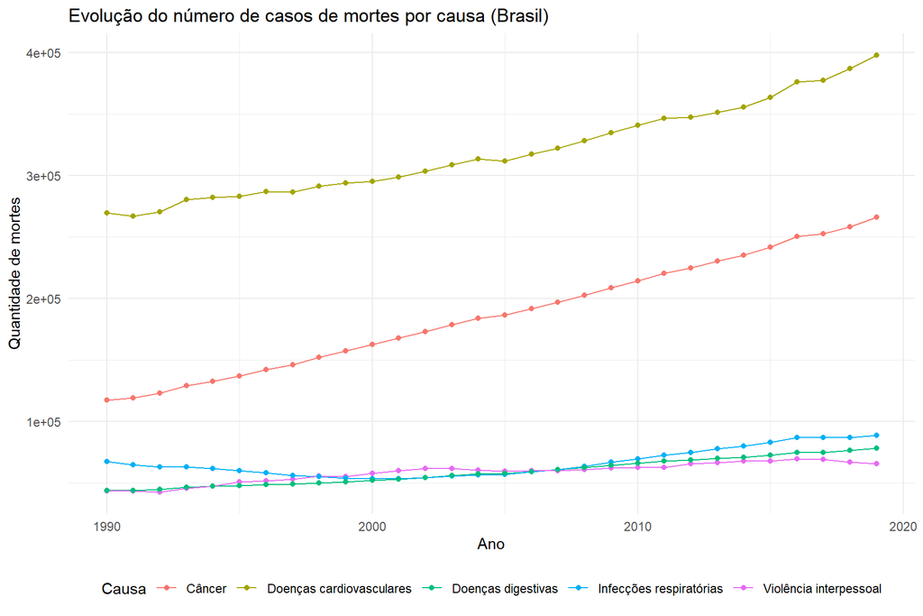

```r
grafico <- ggplot(dados_renomeados, aes(x = Year, y = Mortes, group = Causa, color = Causa)) +
  geom_line() +
  geom_point() +
  theme_minimal() +
  labs(title = "Evolução do número de casos de mortes por causa (Brasil)",
       x = "Ano",
       y = "Quantidade de mortes",
       color = "Causa") +
  theme(legend.position = "bottom")

# Exibindo o gráfico
print(grafico)
```

**Referências**

[https://stackoverflow.com/questions/51449243/how-to-replace-empty-string-with-na-in-r-dataframe”,](https://stackoverflow.com/questions/51449243/how-to-replace-empty-string-with-na-in-r-dataframe%22,) , 8 de abril de 2023

[http://www.cookbook-r.com/Manipulating_data/Converting_data_between_wide_and_long_format/“,](http://www.cookbook-r.com/Manipulating_data/Converting_data_between_wide_and_long_format/%22,) 8 de abril de 2023

[https://www.r-bloggers.com/2022/06/remove-rows-from-the-data-frame-in-r/“,](https://www.r-bloggers.com/2022/06/remove-rows-from-the-data-frame-in-r/%22,) 11 de abril de 2023

[https://sparkbyexamples.com/r-programming/order-dataframe-by-one-descending-and-one-ascending-column-in-r/“,](https://sparkbyexamples.com/r-programming/order-dataframe-by-one-descending-and-one-ascending-column-in-r/%22,) 11 de abril de 2023

[https://cmdlinetips.com/2019/04/how-to-recode-a-column-with-dplyr-in-r/“,](https://cmdlinetips.com/2019/04/how-to-recode-a-column-with-dplyr-in-r/%22,) 11 de abril de 2023

[https://stackoverflow.com/questions/60131993/rename-columns-based-on-vector”,](https://stackoverflow.com/questions/60131993/rename-columns-based-on-vector%22,) 12 de abril de 2023

[https://mode.com/example-gallery/r_horizontal_bar/“,](https://mode.com/example-gallery/r_horizontal_bar/%22,) 12 de abril de 2023

[https://r-graph-gallery.com/connected_scatterplot_ggplot2.html”,](https://r-graph-gallery.com/connected_scatterplot_ggplot2.html%22,) 12 de abril de 2023